# Module 36

#### Contrast SVE:

Signed variance explained (SVE) provides an indication of how similar a set of fold changes are to a gene module’s weight vector. An SVE value of 0.3, for example, indicates that 30% of the variance explained by the entire module set is accounted for by the module in question. Shown here are the SVE values for this module across a compendium of fold changes (contrasts). Extreme SVE values (e.g., > 0.05) indicate that those contrasts specifically induce (orange dots) or specifically repress (blue dots) this module. Examining the experimental conditions being compared in such contrasts (see tables below the figure) may provide insight into the gene module’s function.

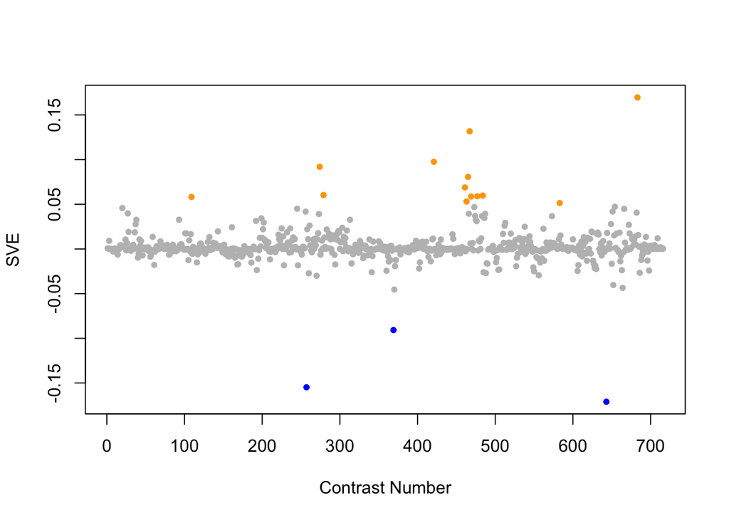

Positive SVE Contrasts:

|  | Contrast.Num | SVE | GEO.GSE | Cond.1 | Cond.2 | Mutation |
| --- | --- | --- | --- | --- | --- | --- |
| GSE12298B.s1t1.vs.s0t1 | 683 | 0.17 | GSE12298 | fenamiphos_low_dose-rep1 | fenamiphos_control-rep1 |  |
| GSE23528A.s1t1.vs.s0t1 | 467 | 0.13 | GSE23528 | Adult at T2 in LD, time-series experiment 3 | Adult at T2, non-entrained control time-series experiment 4 |  |
| GSE28494.s1t2.vs.s0t2 | 421 | 0.10 | GSE28494 | lin-54(n3423) dissected germline 1 | wild-type N2 dissected germline 1 | lin-54 |
| GSE41366B.s1t1.vs.s0t1 | 274 | 0.09 | GSE41366 | low_DDVP-8h_expose-14h_harvest-rep1 | control-8h_expose-14h_harvest-rep1 |  |
| GSE23528A.s1t5.vs.s0t5 | 465 | 0.08 | GSE23528 | Adult at T18 in LD, time-series experiment 3 | Adult at T18, non-entrained control time-series experiment 4 |  |
| GSE23528A.s1t3.vs.s0t3 | 461 | 0.07 | GSE23528 | Adult at T10 in LD, time-series experiment 3 | Adult at T10, non-entrained control time-series experiment 4 |  |
| GSE41366B.s0t2.vs.s0t1 | 279 | 0.06 | GSE41366 | control-8h_expose-20h_harvest-rep1 | control-8h_expose-14h_harvest-rep1 |  |
| GSE23528A.s0t4.vs.s0t1 | 484 | 0.06 | GSE23528 | Adult at T14, non-entrained control time-series experiment 4 | Adult at T2, non-entrained control time-series experiment 4 |  |
| GSE23528A.s1t2.vs.s1t1 | 477 | 0.06 | GSE23528 | Adult at T6 in LD, time-series experiment 3 | Adult at T2 in LD, time-series experiment 3 |  |
| GSE23528A.s1t6.vs.s0t6 | 469 | 0.06 | GSE23528 | Adult at T22 in LD, time-series experiment 3 | Adult at T22, non-entrained control time-series experiment 4 |  |
| GSE54513.s4t1.vs.s2t1 | 109 | 0.06 | GSE54513 | spe-9 OMA-1 IP rep1 | fog-1 OMA-1 IP rep1 |  |
| GSE23528A.s1t4.vs.s0t4 | 463 | 0.05 | GSE23528 | Adult at T14 in LD, time-series experiment 3 | Adult at T14, non-entrained control time-series experiment 4 |  |
| GSE2180.s2t3.vs.s2t1 | 583 | 0.05 | GSE2180 | ms41-1 | ms0-1 |  |

Negative SVE Contrasts:

|  | Contrast.Num | SVE | GEO.GSE | Cond.1 | Cond.2 | Mutation |
| --- | --- | --- | --- | --- | --- | --- |
| GSE16975.s1t1.vs.s0t1 | 643 | -0.17 | GSE16975 | C.elegans hydrogen sulfide sample replicate 1 | C.elegans control sample replicate 1 |  |
| GSE41366A.s1t2.vs.s0t2 | 257 | -0.15 | GSE41366 | low_DDVP-2h_expose-14h_harvest-rep1 | control-2h_expose-14h_harvest-rep1 |  |
| GSE35360B.s1t1.vs.s0t1 | 369 | -0.09 | GSE35360 | HF 3d_0.2_rep1 | HF 3d control_rep1 |  |
| GSE35360B.s2t1.vs.s0t1 | 370 | -0.05 | GSE35360 | HF 3d_2.0_rep1 | HF 3d control_rep1 |  |
| GSE15159.s2t2.vs.s0t2 | 664 | -0.04 | GSE15159 | xpa-1_UV_2007_rep1 | N2_UV_2007_rep1 | xpa-1 |

$~$

#### Contrast SVE, Up-Regulated Genes Only:

Calculating SVE for up-regulated and down-regulated genes separately may be more informative in many cases than projecting the up- and down- gene sets together. This is due to the fact that the weight distribution of many modules is highly skewed, indicating that only one of the hemi-modules may be biologically meaningful (i.e., a set of genes are strongly correlated by only a few genes (or none) are strongly anti-correlated to that set.)

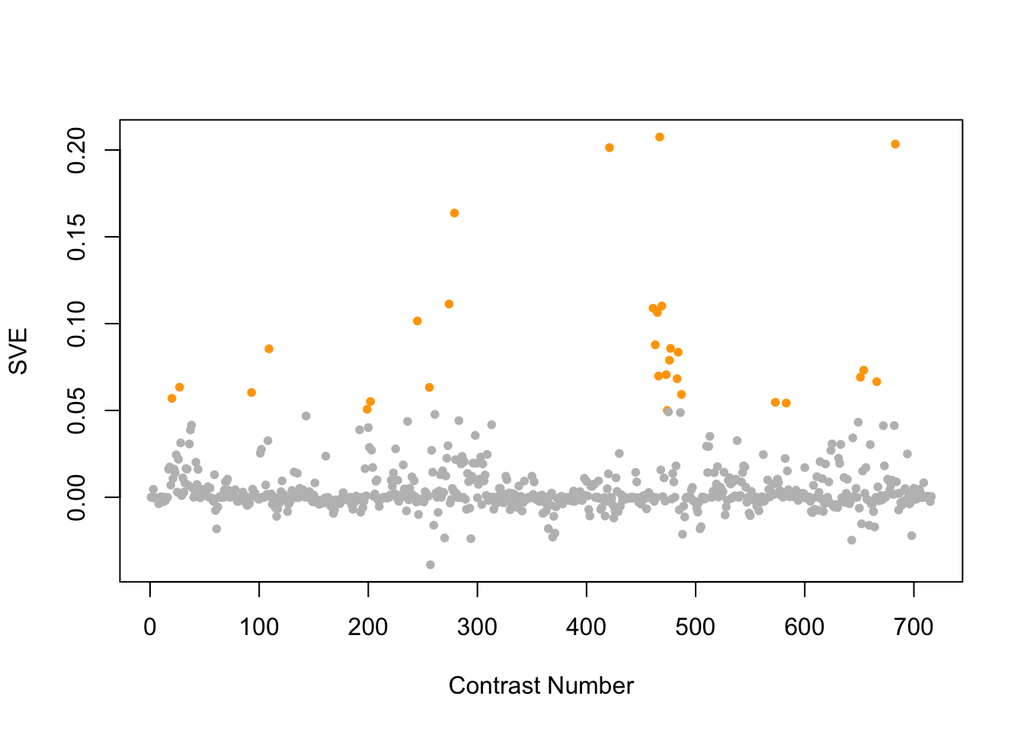

Positive SVE Contrasts:

|  | Contrast.Num | SVE | GEO.GSE | Cond.1 | Cond.2 | Mutation |
| --- | --- | --- | --- | --- | --- | --- |
| GSE23528A.s1t1.vs.s0t1 | 467 | 0.21 | GSE23528 | Adult at T2 in LD, time-series experiment 3 | Adult at T2, non-entrained control time-series experiment 4 |  |
| GSE12298B.s1t1.vs.s0t1 | 683 | 0.20 | GSE12298 | fenamiphos_low_dose-rep1 | fenamiphos_control-rep1 |  |
| GSE28494.s1t2.vs.s0t2 | 421 | 0.20 | GSE28494 | lin-54(n3423) dissected germline 1 | wild-type N2 dissected germline 1 | lin-54 |
| GSE41366B.s0t2.vs.s0t1 | 279 | 0.16 | GSE41366 | control-8h_expose-20h_harvest-rep1 | control-8h_expose-14h_harvest-rep1 |  |
| GSE41366B.s1t1.vs.s0t1 | 274 | 0.11 | GSE41366 | low_DDVP-8h_expose-14h_harvest-rep1 | control-8h_expose-14h_harvest-rep1 |  |
| GSE23528A.s1t6.vs.s0t6 | 469 | 0.11 | GSE23528 | Adult at T22 in LD, time-series experiment 3 | Adult at T22, non-entrained control time-series experiment 4 |  |
| GSE23528A.s1t3.vs.s0t3 | 461 | 0.11 | GSE23528 | Adult at T10 in LD, time-series experiment 3 | Adult at T10, non-entrained control time-series experiment 4 |  |
| GSE23528A.s1t5.vs.s0t5 | 465 | 0.11 | GSE23528 | Adult at T18 in LD, time-series experiment 3 | Adult at T18, non-entrained control time-series experiment 4 |  |
| GSE42592C.s3t3.vs.s3t2 | 245 | 0.10 | GSE42592 | mercury_high_expose-8h_rep1 | mercury_high_expose-4h_rep1 |  |
| GSE23528A.s1t4.vs.s0t4 | 463 | 0.09 | GSE23528 | Adult at T14 in LD, time-series experiment 3 | Adult at T14, non-entrained control time-series experiment 4 |  |
| GSE23528A.s1t2.vs.s1t1 | 477 | 0.09 | GSE23528 | Adult at T6 in LD, time-series experiment 3 | Adult at T2 in LD, time-series experiment 3 |  |
| GSE54513.s4t1.vs.s2t1 | 109 | 0.09 | GSE54513 | spe-9 OMA-1 IP rep1 | fog-1 OMA-1 IP rep1 |  |
| GSE23528A.s0t4.vs.s0t1 | 484 | 0.08 | GSE23528 | Adult at T14, non-entrained control time-series experiment 4 | Adult at T2, non-entrained control time-series experiment 4 |  |
| GSE23528A.s1t6.vs.s1t1 | 476 | 0.08 | GSE23528 | Adult at T22 in LD, time-series experiment 3 | Adult at T2 in LD, time-series experiment 3 |  |
| GSE16405.s4t1.vs.s3t1 | 654 | 0.07 | GSE16405 | xpa-1_1 | nth-1;xpa-1_1 | nth-1 |
| GSE23528A.s1t3.vs.s1t1 | 473 | 0.07 | GSE23528 | Adult at T10 in LD, time-series experiment 3 | Adult at T2 in LD, time-series experiment 3 |  |
| GSE23528A.s2t5.vs.s0t5 | 466 | 0.07 | GSE23528 | Adult at T18 in WC, time-series experiment 1 | Adult at T18, non-entrained control time-series experiment 4 |  |
| GSE16405.s4t1.vs.s1t1 | 651 | 0.07 | GSE16405 | xpa-1_1 | N2_1 | xpa-1 |
| GSE23528A.s0t3.vs.s0t1 | 483 | 0.07 | GSE23528 | Adult at T10, non-entrained control time-series experiment 4 | Adult at T2, non-entrained control time-series experiment 4 |  |
| GSE15159.s0t2.vs.s0t1 | 666 | 0.07 | GSE15159 | N2_UV_2007_rep1 | N2_control_2007_rep1 |  |
| GSE9665.s6t2.vs.s0t2 | 27 | 0.06 | GSE9665 | mex-3 nhr-25 186 A | mex-3 186 A | nhr-25 |
| GSE41366A.s2t2.vs.s0t2 | 256 | 0.06 | GSE41366 | high_DDVP-2h_expose-14h_harvest-rep1 | control-2h_expose-14h_harvest-rep1 |  |
| GSE5801.s3t1.vs.s1t1 | 93 | 0.06 | GSE5801 | daf2pmk1_RepA | daf2_RepA | pmk-1 |
| GSE23528A.s0t2.vs.s0t1 | 487 | 0.06 | GSE23528 | Adult at T6, non-entrained control time-series experiment 4 | Adult at T2, non-entrained control time-series experiment 4 |  |
| GSE9665.s9t1.vs.s0t1 | 20 | 0.06 | GSE9665 | mex-3 scrt-1 143 A | mex-3 143 A | scrt-1 |
| GSE43959.s1t2.vs.s1t1 | 202 | 0.06 | GSE43959 | N2 gravid adult on E. coli OP50 rep 1 | N2 young adult on E. coli OP50 rep 1 |  |
| GSE2180.s1t2.vs.s1t1 | 573 | 0.05 | GSE2180 | 23-1 | 00B |  |
| GSE2180.s2t3.vs.s2t1 | 583 | 0.05 | GSE2180 | ms41-1 | ms0-1 |  |
| GSE43959.s1t2.vs.s4t2 | 199 | 0.05 | GSE43959 | N2 gravid adult on E. coli OP50 rep 1 | N2 gravid adult on 1:1000 Comamonas DA1877 rep 1 |  |
| GSE23528A.s1t4.vs.s1t1 | 474 | 0.05 | GSE23528 | Adult at T14 in LD, time-series experiment 3 | Adult at T2 in LD, time-series experiment 3 |  |

Negative SVE Contrasts:

|  | Contrast.Num | SVE | GEO.GSE | Cond.1 | Cond.2 | Mutation |
| --- | --- | --- | --- | --- | --- | --- |
| GSE41366A.s1t2.vs.s0t2 | 257 | -0.04 | GSE41366 | low_DDVP-2h_expose-14h_harvest-rep1 | control-2h_expose-14h_harvest-rep1 |  |
| GSE16975.s1t1.vs.s0t1 | 643 | -0.02 | GSE16975 | C.elegans hydrogen sulfide sample replicate 1 | C.elegans control sample replicate 1 |  |
| GSE41366C.s1t3.vs.s0t3 | 294 | -0.02 | GSE41366 | low_DDVP-continuous_expose-14h_harvest-rep1 | control-continuous_expose-8h_harvest-rep1 |  |
| GSE41366A.s1t2.vs.s1t1 | 270 | -0.02 | GSE41366 | low_DDVP-2h_expose-14h_harvest-rep1 | low_DDVP-2h_expose-8h_harvest-rep1 |  |
| GSE35360B.s1t1.vs.s0t1 | 369 | -0.02 | GSE35360 | HF 3d_0.2_rep1 | HF 3d control_rep1 |  |

$~$

#### Contrast SVE, Down-Regulated Genes Only:

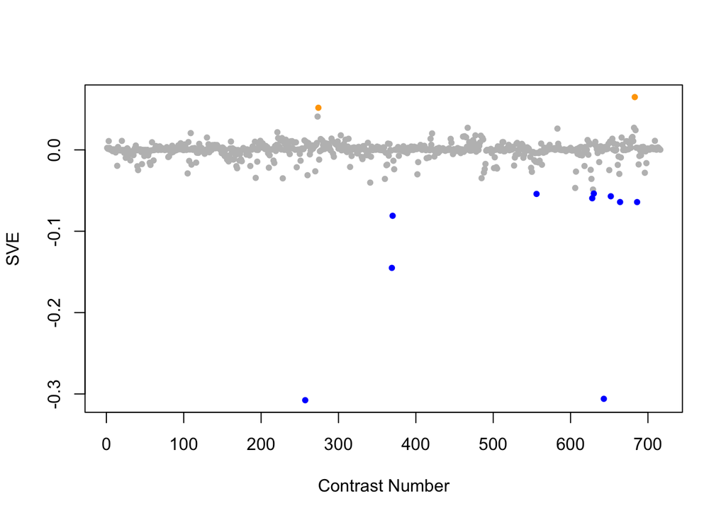

Positive SVE Contrasts:

|  | Contrast.Num | SVE | GEO.GSE | Cond.1 | Cond.2 | Mutation |
| --- | --- | --- | --- | --- | --- | --- |
| GSE12298B.s1t1.vs.s0t1 | 683 | 0.06 | GSE12298 | fenamiphos_low_dose-rep1 | fenamiphos_control-rep1 |  |
| GSE41366B.s1t1.vs.s0t1 | 274 | 0.05 | GSE41366 | low_DDVP-8h_expose-14h_harvest-rep1 | control-8h_expose-14h_harvest-rep1 |  |
| GSE41366B.s2t1.vs.s0t1 | 273 | 0.04 | GSE41366 | high_DDVP-8h_expose-14h_harvest-rep1 | control-8h_expose-14h_harvest-rep1 |  |
| GSE12298B.s3t1.vs.s0t1 | 682 | 0.03 | GSE12298 | fenamiphos_high_dose-rep1 | fenamiphos_control-rep1 |  |
| GSE23528A.s1t1.vs.s0t1 | 467 | 0.03 | GSE23528 | Adult at T2 in LD, time-series experiment 3 | Adult at T2, non-entrained control time-series experiment 4 |  |

Negative SVE Contrasts:

|  | Contrast.Num | SVE | GEO.GSE | Cond.1 | Cond.2 | Mutation |
| --- | --- | --- | --- | --- | --- | --- |
| GSE41366A.s1t2.vs.s0t2 | 257 | -0.31 | GSE41366 | low_DDVP-2h_expose-14h_harvest-rep1 | control-2h_expose-14h_harvest-rep1 |  |
| GSE16975.s1t1.vs.s0t1 | 643 | -0.31 | GSE16975 | C.elegans hydrogen sulfide sample replicate 1 | C.elegans control sample replicate 1 |  |
| GSE35360B.s1t1.vs.s0t1 | 369 | -0.15 | GSE35360 | HF 3d_0.2_rep1 | HF 3d control_rep1 |  |
| GSE35360B.s2t1.vs.s0t1 | 370 | -0.08 | GSE35360 | HF 3d_2.0_rep1 | HF 3d control_rep1 |  |
| GSE12298C.s1t1.vs.s0t1 | 686 | -0.06 | GSE12298 | mefloquine_low_dose-rep1 | mefloquine_control-rep1 |  |
| GSE15159.s2t2.vs.s0t2 | 664 | -0.06 | GSE15159 | xpa-1_UV_2007_rep1 | N2_UV_2007_rep1 | xpa-1 |
| GSE19310A.s1t1.vs.s0t1 | 628 | -0.06 | GSE19310 | osm-11(n1604) at iso, rep1 | N2 at iso, rep1 | osm-11 |
| GSE16405.s3t1.vs.s2t1 | 652 | -0.06 | GSE16405 | nth-1;xpa-1_1 | nth-1_1 | xpa-1 |
| GSE2180.s4t4.vs.s3t4 | 556 | -0.05 | GSE2180 | pp53-1 | p53-2 |  |
| GSE19310A.s3t1.vs.s0t1 | 630 | -0.05 | GSE19310 | osm-8(n1518) at iso, rep1 | N2 at iso, rep1 | osm-8 |

$~$

$~$

#### GO Term Enrichment:

This analysis tests each hemi-module for enrichment of specific GO terms. Only gene-level annotations (e.g., as would be found on the gene’s page in Wormbase) are tested - the hierarchical structure of the GO ontology is not taken into account.

*Note: At least the top two most enriched terms from each GO domain (BP/MF/CC) are shown, even when not statistically significant.*

##### Enriched GO terms: Hemi-module A

| ID | GO.Term | GO Domain | Raw p-value | Adj p-value |
| --- | --- | --- | --- | --- |
| [GO_0006281](http://amigo.geneontology.org/amigo/term/GO:0006281) | DNA repair | BP | 4.97e-21 | 1.81e-17 |
| [GO_0006974](http://amigo.geneontology.org/amigo/term/GO:0006974) | cellular response to DNA damage stimulus | BP | 2.38e-15 | 4.34e-12 |
| [GO_0007049](http://amigo.geneontology.org/amigo/term/GO:0007049) | cell cycle | BP | 3.15e-09 | 3.82e-06 |
| [GO_0051321](http://amigo.geneontology.org/amigo/term/GO:0051321) | meiotic cell cycle | BP | 1.60e-08 | 1.45e-05 |
| [GO_0000070](http://amigo.geneontology.org/amigo/term/GO:0000070) | mitotic sister chromatid segregation | BP | 9.97e-08 | 6.65e-05 |
| [GO_0006310](http://amigo.geneontology.org/amigo/term/GO:0006310) | DNA recombination | BP | 1.10e-07 | 6.65e-05 |
| [GO_0007186](http://amigo.geneontology.org/amigo/term/GO:0007186) | G protein-coupled receptor signaling pathway | BP | 1.97e-07 | 1.03e-04 |
| [GO_0051301](http://amigo.geneontology.org/amigo/term/GO:0051301) | cell division | BP | 2.85e-07 | 1.30e-04 |
| [GO_0040027](http://amigo.geneontology.org/amigo/term/GO:0040027) | negative regulation of vulval development | BP | 3.45e-07 | 1.39e-04 |
| [GO_0002119](http://amigo.geneontology.org/amigo/term/GO:0002119) | nematode larval development | BP | 3.81e-07 | 1.39e-04 |
| [GO_0006397](http://amigo.geneontology.org/amigo/term/GO:0006397) | mRNA processing | BP | 9.70e-07 | 3.21e-04 |
| [GO_0007059](http://amigo.geneontology.org/amigo/term/GO:0007059) | chromosome segregation | BP | 2.11e-06 | 6.41e-04 |
| [GO_0051276](http://amigo.geneontology.org/amigo/term/GO:0051276) | chromosome organization | BP | 2.95e-06 | 8.06e-04 |
| [GO_0032508](http://amigo.geneontology.org/amigo/term/GO:0032508) | DNA duplex unwinding | BP | 3.10e-06 | 8.06e-04 |
| [GO_0006260](http://amigo.geneontology.org/amigo/term/GO:0006260) | DNA replication | BP | 5.46e-06 | 1.33e-03 |
| [GO_0106074](http://amigo.geneontology.org/amigo/term/GO:0106074) | aminoacyl-tRNA metabolism involved in translational fidelity | BP | 6.45e-06 | 1.47e-03 |
| [GO_0030422](http://amigo.geneontology.org/amigo/term/GO:0030422) | production of siRNA involved in RNA interference | BP | 7.76e-06 | 1.66e-03 |
| [GO_0090305](http://amigo.geneontology.org/amigo/term/GO:0090305) | nucleic acid phosphodiester bond hydrolysis | BP | 9.10e-06 | 1.84e-03 |
| [GO_0006396](http://amigo.geneontology.org/amigo/term/GO:0006396) | RNA processing | BP | 1.25e-05 | 2.40e-03 |
| [GO_0000724](http://amigo.geneontology.org/amigo/term/GO:0000724) | double-strand break repair via homologous recombination | BP | 1.60e-05 | 2.92e-03 |
| [GO_0007076](http://amigo.geneontology.org/amigo/term/GO:0007076) | mitotic chromosome condensation | BP | 2.30e-05 | 3.81e-03 |
| [GO_0031048](http://amigo.geneontology.org/amigo/term/GO:0031048) | chromatin silencing by small RNA | BP | 2.30e-05 | 3.81e-03 |
| [GO_0000398](http://amigo.geneontology.org/amigo/term/GO:0000398) | mRNA splicing, via spliceosome | BP | 2.66e-05 | 4.22e-03 |
| [GO_0016246](http://amigo.geneontology.org/amigo/term/GO:0016246) | RNA interference | BP | 3.18e-05 | 4.82e-03 |
| [GO_0090501](http://amigo.geneontology.org/amigo/term/GO:0090501) | RNA phosphodiester bond hydrolysis | BP | 3.72e-05 | 5.42e-03 |
| [GO_0006287](http://amigo.geneontology.org/amigo/term/GO:0006287) | base-excision repair, gap-filling | BP | 4.57e-05 | 6.16e-03 |
| [GO_0016476](http://amigo.geneontology.org/amigo/term/GO:0016476) | regulation of embryonic cell shape | BP | 4.57e-05 | 6.16e-03 |
| [GO_0000003](http://amigo.geneontology.org/amigo/term/GO:0000003) | reproduction | BP | 5.00e-05 | 6.50e-03 |
| [GO_0016567](http://amigo.geneontology.org/amigo/term/GO:0016567) | protein ubiquitination | BP | 1.01e-04 | 1.27e-02 |
| [GO_0007155](http://amigo.geneontology.org/amigo/term/GO:0007155) | cell adhesion | BP | 1.22e-04 | 1.48e-02 |

[output cut: 128 more lines]

##### Enriched GO terms: Hemi-module B

| ID | GO.Term | GO Domain | Raw p-value | Adj p-value |
| --- | --- | --- | --- | --- |
| [GO_0035279](http://amigo.geneontology.org/amigo/term/GO:0035279) | mRNA cleavage involved in gene silencing by miRNA | BP | 1.50e-03 | 1.00e+00 |
| [GO_0070922](http://amigo.geneontology.org/amigo/term/GO:0070922) | small RNA loading onto RISC | BP | 1.50e-03 | 1.00e+00 |
| [GO_0004363](http://amigo.geneontology.org/amigo/term/GO:0004363) | glutathione synthase activity | MF | 7.48e-04 | 7.64e-01 |
| [GO_0016892](http://amigo.geneontology.org/amigo/term/GO:0016892) | endoribonuclease activity, producing 3’-phosphomonoesters | MF | 1.50e-03 | 7.64e-01 |
| [GO_0031588](http://amigo.geneontology.org/amigo/term/GO:0031588) | nucleotide-activated protein kinase complex | CC | 2.24e-03 | 1.00e+00 |
| [GO_0005730](http://amigo.geneontology.org/amigo/term/GO:0005730) | nucleolus | CC | 4.40e-03 | 1.00e+00 |

$~$

$~$

#### Tissue Enrichment:

This analysis tests each hemi-module for enrichment of genes associated with anatomy terms. Negative enrichment scores indicate fewer hemi-module genes than expected by random chance were associated with the anatomy term in question.

##### Enriched tissues: Hemi-module A

| ID | Anatomy.Term | Definition | Raw p-value | Adj p-value |
| --- | --- | --- | --- | --- |
| [WBbt_0005784](https://wormbase.org/species/all/anatomy_term/WBbt:0005784) | germ line | cell line which early in development becomes differentiated from the remaining somatic cell line, and alone has the potential to undergo meiosis and form gametes. | 3.56e-05 | 6.93e-02 |
| [WBbt_0008112](https://wormbase.org/species/all/anatomy_term/WBbt:0008112) | P3.p hermaphrodite | descendent cell of post-embryonic blast cell P3, posterior in hermaphrodite. | 9.82e-05 | 6.93e-02 |
| [WBbt_0008117](https://wormbase.org/species/all/anatomy_term/WBbt:0008117) | P4.p hermaphrodite | descendent cell of post-embryonic blast cell P4, posterior, in hermaphrodite. | 9.82e-05 | 6.93e-02 |
| [WBbt_0008133](https://wormbase.org/species/all/anatomy_term/WBbt:0008133) | P8.p hermaphrodite |  | 1.14e-04 | 6.93e-02 |
| [WBbt_0008121](https://wormbase.org/species/all/anatomy_term/WBbt:0008121) | P5.p hermaphrodite | descendent cell of post-embryonic blast cell P5, posterior, in hermaphrodite. | 1.75e-04 | 8.11e-02 |
| [WBbt_0008129](https://wormbase.org/species/all/anatomy_term/WBbt:0008129) | P7.p hermaphrodite |  | 2.00e-04 | 8.11e-02 |
| [WBbt_0008125](https://wormbase.org/species/all/anatomy_term/WBbt:0008125) | P6.p hermaphrodite |  | 2.61e-04 | 9.06e-02 |

##### Enriched tissues: Hemi-module B

No significant annotations.

$~$

$~$

#### HOMER promoter motif enrichment:

This analysis tests each hemi-module for enrichment of 108 known *C. elegans* transcription factor binding site motifs (see [108 CE motifs](https://katiepod.github.io//all.worm.motifs.html)) using the HOMER (Hypergeometric Optimization of Motif EnRichment) software (see [PMID:20513432](https://pubmed.ncbi.nlm.nih.gov/20513432)). HOMER was run using default parameters on sequences 1 kb upstream of the transcription start site.

##### Motif enrichment: Hemi-module A

Total target sequences = 466  
Total background sequences = 39541  
* - possible false positive

Rank

Motif

P-value

log P-pvalue

% of Targets

% of Background

STD(Bg STD)

Best Match/Details

Motif File

1

[figure not shown]

1e-16

-3.724e+01

62.88%

43.58%

277.1bp (346.4bp)

DPL-1(E2F)/cElegans-Adult-ChIP-Seq(modEncode)/Homer(0.753)  
[More Information](https://katiepod.github.io/HomerResults/m36_a_hemi_genes.txt.out.1kb/homerResults/motif1.info.html) | [Similar Motifs Found](https://katiepod.github.io/HomerResults/m36_a_hemi_genes.txt.out.1kb/homerResults/motif1.similar.html)

[motif file (matrix)](https://katiepod.github.io/HomerResults/m36_a_hemi_genes.txt.out.1kb/homerResults/motif1.motif)

2

[figure not shown]

1e-13

-3.186e+01

25.11%

12.08%

283.4bp (332.6bp)

eor-1/MA0543.1/Jaspar(0.714)  
[More Information](https://katiepod.github.io/HomerResults/m36_a_hemi_genes.txt.out.1kb/homerResults/motif2.info.html) | [Similar Motifs Found](https://katiepod.github.io/HomerResults/m36_a_hemi_genes.txt.out.1kb/homerResults/motif2.similar.html)

[motif file (matrix)](https://katiepod.github.io/HomerResults/m36_a_hemi_genes.txt.out.1kb/homerResults/motif2.motif)

3

[figure not shown]

1e-13

-3.178e+01

48.50%

31.38%

283.7bp (338.4bp)

blmp-1/MA0537.1/Jaspar(0.614)  
[More Information](https://katiepod.github.io/HomerResults/m36_a_hemi_genes.txt.out.1kb/homerResults/motif3.info.html) | [Similar Motifs Found](https://katiepod.github.io/HomerResults/m36_a_hemi_genes.txt.out.1kb/homerResults/motif3.similar.html)

[motif file (matrix)](https://katiepod.github.io/HomerResults/m36_a_hemi_genes.txt.out.1kb/homerResults/motif3.motif)

4

[figure not shown]

1e-13

-3.131e+01

47.00%

30.15%

295.8bp (319.6bp)

MF0005.1_Forkhead_class/Jaspar(0.790)  
[More Information](https://katiepod.github.io/HomerResults/m36_a_hemi_genes.txt.out.1kb/homerResults/motif4.info.html) | [Similar Motifs Found](https://katiepod.github.io/HomerResults/m36_a_hemi_genes.txt.out.1kb/homerResults/motif4.similar.html)

[motif file (matrix)](https://katiepod.github.io/HomerResults/m36_a_hemi_genes.txt.out.1kb/homerResults/motif4.motif)

5

[figure not shown]

1e-13

-3.127e+01

10.52%

2.88%

282.2bp (339.6bp)

POL008.1_DCE_S_I/Jaspar(0.619)  
[More Information](https://katiepod.github.io/HomerResults/m36_a_hemi_genes.txt.out.1kb/homerResults/motif5.info.html) | [Similar Motifs Found](https://katiepod.github.io/HomerResults/m36_a_hemi_genes.txt.out.1kb/homerResults/motif5.similar.html)

[motif file (matrix)](https://katiepod.github.io/HomerResults/m36_a_hemi_genes.txt.out.1kb/homerResults/motif5.motif)

6

[figure not shown]

1e-13

-3.027e+01

4.08%

0.36%

273.4bp (336.8bp)

MF0010.1_Homeobox_class/Jaspar(0.619)  
[More Information](https://katiepod.github.io/HomerResults/m36_a_hemi_genes.txt.out.1kb/homerResults/motif6.info.html) | [Similar Motifs Found](https://katiepod.github.io/HomerResults/m36_a_hemi_genes.txt.out.1kb/homerResults/motif6.similar.html)

[motif file (matrix)](https://katiepod.github.io/HomerResults/m36_a_hemi_genes.txt.out.1kb/homerResults/motif6.motif)

7

[figure not shown]

1e-12

-2.906e+01

10.94%

3.29%

287.1bp (333.5bp)

LIN-15B(Zf)/cElegans-L3-LIN15B-ChIP-Seq(modEncode)/Homer(0.703)  
[More Information](https://katiepod.github.io/HomerResults/m36_a_hemi_genes.txt.out.1kb/homerResults/motif7.info.html) | [Similar Motifs Found](https://katiepod.github.io/HomerResults/m36_a_hemi_genes.txt.out.1kb/homerResults/motif7.similar.html)

[motif file (matrix)](https://katiepod.github.io/HomerResults/m36_a_hemi_genes.txt.out.1kb/homerResults/motif7.motif)

8

[figure not shown]

1e-12

-2.881e+01

5.58%

0.86%

238.0bp (323.0bp)

GEI-11(Myb?)/cElegans-L4-GEI11-ChIP-Seq(modEncode)/Homer(0.498)  
[More Information](https://katiepod.github.io/HomerResults/m36_a_hemi_genes.txt.out.1kb/homerResults/motif8.info.html) | [Similar Motifs Found](https://katiepod.github.io/HomerResults/m36_a_hemi_genes.txt.out.1kb/homerResults/motif8.similar.html)

[motif file (matrix)](https://katiepod.github.io/HomerResults/m36_a_hemi_genes.txt.out.1kb/homerResults/motif8.motif)

9

[figure not shown]

1e-12

-2.853e+01

4.72%

0.59%

284.9bp (352.4bp)

fkh-9/MA1440.1/Jaspar(0.692)  
[More Information](https://katiepod.github.io/HomerResults/m36_a_hemi_genes.txt.out.1kb/homerResults/motif9.info.html) | [Similar Motifs Found](https://katiepod.github.io/HomerResults/m36_a_hemi_genes.txt.out.1kb/homerResults/motif9.similar.html)

[motif file (matrix)](https://katiepod.github.io/HomerResults/m36_a_hemi_genes.txt.out.1kb/homerResults/motif9.motif)

10 *

[figure not shown]

1e-11

-2.654e+01

2.58%

0.12%

202.2bp (325.1bp)

EGL-5(Homeobox)/cElegans-L3-EGL5-ChIP-Seq(modEncode)/Homer(0.625)  
[More Information](https://katiepod.github.io/HomerResults/m36_a_hemi_genes.txt.out.1kb/homerResults/motif10.info.html) | [Similar Motifs Found](https://katiepod.github.io/HomerResults/m36_a_hemi_genes.txt.out.1kb/homerResults/motif10.similar.html)

[motif file (matrix)](https://katiepod.github.io/HomerResults/m36_a_hemi_genes.txt.out.1kb/homerResults/motif10.motif)

11 *

[figure not shown]

1e-11

-2.607e+01

21.24%

10.31%

282.5bp (330.0bp)

POL009.1_DCE_S_II/Jaspar(0.638)  
[More Information](https://katiepod.github.io/HomerResults/m36_a_hemi_genes.txt.out.1kb/homerResults/motif11.info.html) | [Similar Motifs Found](https://katiepod.github.io/HomerResults/m36_a_hemi_genes.txt.out.1kb/homerResults/motif11.similar.html)

[motif file (matrix)](https://katiepod.github.io/HomerResults/m36_a_hemi_genes.txt.out.1kb/homerResults/motif11.motif)

12 *

[figure not shown]

1e-11

-2.595e+01

66.09%

50.29%

289.1bp (314.1bp)

MF0010.1_Homeobox_class/Jaspar(0.606)  
[More Information](https://katiepod.github.io/HomerResults/m36_a_hemi_genes.txt.out.1kb/homerResults/motif12.info.html) | [Similar Motifs Found](https://katiepod.github.io/HomerResults/m36_a_hemi_genes.txt.out.1kb/homerResults/motif12.similar.html)

[motif file (matrix)](https://katiepod.github.io/HomerResults/m36_a_hemi_genes.txt.out.1kb/homerResults/motif12.motif)

13 *

[figure not shown]

1e-11

-2.591e+01

8.80%

2.44%

275.4bp (325.3bp)

GEI-11(Myb?)/cElegans-L4-GEI11-ChIP-Seq(modEncode)/Homer(0.543)  
[More Information](https://katiepod.github.io/HomerResults/m36_a_hemi_genes.txt.out.1kb/homerResults/motif13.info.html) | [Similar Motifs Found](https://katiepod.github.io/HomerResults/m36_a_hemi_genes.txt.out.1kb/homerResults/motif13.similar.html)

[motif file (matrix)](https://katiepod.github.io/HomerResults/m36_a_hemi_genes.txt.out.1kb/homerResults/motif13.motif)

14 *

[figure not shown]

1e-10

-2.489e+01

3.43%

0.33%

281.2bp (342.2bp)

PL0004.1_hlh-27/Jaspar(0.549)  
[More Information](https://katiepod.github.io/HomerResults/m36_a_hemi_genes.txt.out.1kb/homerResults/motif14.info.html) | [Similar Motifs Found](https://katiepod.github.io/HomerResults/m36_a_hemi_genes.txt.out.1kb/homerResults/motif14.similar.html)

[motif file (matrix)](https://katiepod.github.io/HomerResults/m36_a_hemi_genes.txt.out.1kb/homerResults/motif14.motif)

15 *

[figure not shown]

1e-10

-2.344e+01

1.29%

0.01%

343.3bp (100.6bp)

lin-14/MA0261.1/Jaspar(0.670)  
[More Information](https://katiepod.github.io/HomerResults/m36_a_hemi_genes.txt.out.1kb/homerResults/motif15.info.html) | [Similar Motifs Found](https://katiepod.github.io/HomerResults/m36_a_hemi_genes.txt.out.1kb/homerResults/motif15.similar.html)

[motif file (matrix)](https://katiepod.github.io/HomerResults/m36_a_hemi_genes.txt.out.1kb/homerResults/motif15.motif)

16 *

[figure not shown]

1e-9

-2.237e+01

7.08%

1.86%

228.7bp (312.5bp)

unc-86/MA0926.1/Jaspar(0.503)  
[More Information](https://katiepod.github.io/HomerResults/m36_a_hemi_genes.txt.out.1kb/homerResults/motif16.info.html) | [Similar Motifs Found](https://katiepod.github.io/HomerResults/m36_a_hemi_genes.txt.out.1kb/homerResults/motif16.similar.html)

[motif file (matrix)](https://katiepod.github.io/HomerResults/m36_a_hemi_genes.txt.out.1kb/homerResults/motif16.motif)

17 *

[figure not shown]

1e-9

-2.204e+01

33.26%

20.72%

289.2bp (320.5bp)

pha-4/MA0546.1/Jaspar(0.655)  
[More Information](https://katiepod.github.io/HomerResults/m36_a_hemi_genes.txt.out.1kb/homerResults/motif17.info.html) | [Similar Motifs Found](https://katiepod.github.io/HomerResults/m36_a_hemi_genes.txt.out.1kb/homerResults/motif17.similar.html)

[motif file (matrix)](https://katiepod.github.io/HomerResults/m36_a_hemi_genes.txt.out.1kb/homerResults/motif17.motif)

18 *

[figure not shown]

1e-9

-2.144e+01

6.22%

1.52%

230.7bp (317.6bp)

MF0001.1_ETS_class/Jaspar(0.612)  
[More Information](https://katiepod.github.io/HomerResults/m36_a_hemi_genes.txt.out.1kb/homerResults/motif18.info.html) | [Similar Motifs Found](https://katiepod.github.io/HomerResults/m36_a_hemi_genes.txt.out.1kb/homerResults/motif18.similar.html)

[motif file (matrix)](https://katiepod.github.io/HomerResults/m36_a_hemi_genes.txt.out.1kb/homerResults/motif18.motif)

19 *

[figure not shown]

1e-9

-2.129e+01

23.82%

13.23%

277.5bp (319.4bp)

fkh-2/MA0920.1/Jaspar(0.680)  
[More Information](https://katiepod.github.io/HomerResults/m36_a_hemi_genes.txt.out.1kb/homerResults/motif19.info.html) | [Similar Motifs Found](https://katiepod.github.io/HomerResults/m36_a_hemi_genes.txt.out.1kb/homerResults/motif19.similar.html)

[motif file (matrix)](https://katiepod.github.io/HomerResults/m36_a_hemi_genes.txt.out.1kb/homerResults/motif19.motif)

20 *

[figure not shown]

1e-9

-2.095e+01

24.03%

13.48%

288.7bp (339.7bp)

EGL-5(Homeobox)/cElegans-L3-EGL5-ChIP-Seq(modEncode)/Homer(0.581)  
[More Information](https://katiepod.github.io/HomerResults/m36_a_hemi_genes.txt.out.1kb/homerResults/motif20.info.html) | [Similar Motifs Found](https://katiepod.github.io/HomerResults/m36_a_hemi_genes.txt.out.1kb/homerResults/motif20.similar.html)

[motif file (matrix)](https://katiepod.github.io/HomerResults/m36_a_hemi_genes.txt.out.1kb/homerResults/motif20.motif)

21 *

[figure not shown]

1e-9

-2.091e+01

32.62%

20.50%

266.9bp (313.5bp)

fkh-9/MA1440.1/Jaspar(0.780)  
[More Information](https://katiepod.github.io/HomerResults/m36_a_hemi_genes.txt.out.1kb/homerResults/motif21.info.html) | [Similar Motifs Found](https://katiepod.github.io/HomerResults/m36_a_hemi_genes.txt.out.1kb/homerResults/motif21.similar.html)

[motif file (matrix)](https://katiepod.github.io/HomerResults/m36_a_hemi_genes.txt.out.1kb/homerResults/motif21.motif)

22 *

[figure not shown]

1e-8

-1.992e+01

3.65%

0.54%

253.9bp (292.1bp)

POL003.1_GC-box/Jaspar(0.603)  
[More Information](https://katiepod.github.io/HomerResults/m36_a_hemi_genes.txt.out.1kb/homerResults/motif22.info.html) | [Similar Motifs Found](https://katiepod.github.io/HomerResults/m36_a_hemi_genes.txt.out.1kb/homerResults/motif22.similar.html)

[motif file (matrix)](https://katiepod.github.io/HomerResults/m36_a_hemi_genes.txt.out.1kb/homerResults/motif22.motif)

23 *

[figure not shown]

1e-8

-1.949e+01

1.72%

0.06%

263.9bp (361.1bp)

ceh-22/MA0264.1/Jaspar(0.550)  
[More Information](https://katiepod.github.io/HomerResults/m36_a_hemi_genes.txt.out.1kb/homerResults/motif23.info.html) | [Similar Motifs Found](https://katiepod.github.io/HomerResults/m36_a_hemi_genes.txt.out.1kb/homerResults/motif23.similar.html)

[motif file (matrix)](https://katiepod.github.io/HomerResults/m36_a_hemi_genes.txt.out.1kb/homerResults/motif23.motif)

24 *

[figure not shown]

1e-8

-1.900e+01

4.51%

0.91%

288.9bp (320.4bp)

ceh-38/MA1699.1/Jaspar(0.626)  
[More Information](https://katiepod.github.io/HomerResults/m36_a_hemi_genes.txt.out.1kb/homerResults/motif24.info.html) | [Similar Motifs Found](https://katiepod.github.io/HomerResults/m36_a_hemi_genes.txt.out.1kb/homerResults/motif24.similar.html)

[motif file (matrix)](https://katiepod.github.io/HomerResults/m36_a_hemi_genes.txt.out.1kb/homerResults/motif24.motif)

25 *

[figure not shown]

1e-7

-1.826e+01

13.73%

6.39%

262.0bp (332.1bp)

lin-14/MA0261.1/Jaspar(0.582)  
[More Information](https://katiepod.github.io/HomerResults/m36_a_hemi_genes.txt.out.1kb/homerResults/motif25.info.html) | [Similar Motifs Found](https://katiepod.github.io/HomerResults/m36_a_hemi_genes.txt.out.1kb/homerResults/motif25.similar.html)

[motif file (matrix)](https://katiepod.github.io/HomerResults/m36_a_hemi_genes.txt.out.1kb/homerResults/motif25.motif)

26 *

[figure not shown]

1e-7

-1.782e+01

15.88%

8.00%

286.5bp (334.9bp)

blmp-1/MA0537.1/Jaspar(0.768)  
[More Information](https://katiepod.github.io/HomerResults/m36_a_hemi_genes.txt.out.1kb/homerResults/motif26.info.html) | [Similar Motifs Found](https://katiepod.github.io/HomerResults/m36_a_hemi_genes.txt.out.1kb/homerResults/motif26.similar.html)

[motif file (matrix)](https://katiepod.github.io/HomerResults/m36_a_hemi_genes.txt.out.1kb/homerResults/motif26.motif)

27 *

[figure not shown]

1e-7

-1.640e+01

15.02%

7.66%

255.7bp (315.0bp)

atf-7/MA1438.1/Jaspar(0.540)  
[More Information](https://katiepod.github.io/HomerResults/m36_a_hemi_genes.txt.out.1kb/homerResults/motif27.info.html) | [Similar Motifs Found](https://katiepod.github.io/HomerResults/m36_a_hemi_genes.txt.out.1kb/homerResults/motif27.similar.html)

[motif file (matrix)](https://katiepod.github.io/HomerResults/m36_a_hemi_genes.txt.out.1kb/homerResults/motif27.motif)

28 *

[figure not shown]

1e-7

-1.621e+01

1.07%

0.02%

231.5bp (394.7bp)

POL008.1_DCE_S_I/Jaspar(0.506)  
[More Information](https://katiepod.github.io/HomerResults/m36_a_hemi_genes.txt.out.1kb/homerResults/motif28.info.html) | [Similar Motifs Found](https://katiepod.github.io/HomerResults/m36_a_hemi_genes.txt.out.1kb/homerResults/motif28.similar.html)

[motif file (matrix)](https://katiepod.github.io/HomerResults/m36_a_hemi_genes.txt.out.1kb/homerResults/motif28.motif)

29 *

[figure not shown]

1e-6

-1.543e+01

11.80%

5.55%

262.5bp (337.4bp)

MF0002.1_bZIP_CREB/G-box-like_subclass/Jaspar(0.724)  
[More Information](https://katiepod.github.io/HomerResults/m36_a_hemi_genes.txt.out.1kb/homerResults/motif29.info.html) | [Similar Motifs Found](https://katiepod.github.io/HomerResults/m36_a_hemi_genes.txt.out.1kb/homerResults/motif29.similar.html)

[motif file (matrix)](https://katiepod.github.io/HomerResults/m36_a_hemi_genes.txt.out.1kb/homerResults/motif29.motif)

30 *

[figure not shown]

1e-6

-1.393e+01

2.58%

0.40%

289.0bp (300.6bp)

PL0014.1_mxl-1::mdl-1/Jaspar(0.557)  
[More Information](https://katiepod.github.io/HomerResults/m36_a_hemi_genes.txt.out.1kb/homerResults/motif30.info.html) | [Similar Motifs Found](https://katiepod.github.io/HomerResults/m36_a_hemi_genes.txt.out.1kb/homerResults/motif30.similar.html)

[motif file (matrix)](https://katiepod.github.io/HomerResults/m36_a_hemi_genes.txt.out.1kb/homerResults/motif30.motif)

31 *

[figure not shown]

1e-5

-1.361e+01

4.08%

1.06%

233.9bp (313.7bp)

MF0008.1_MADS_class/Jaspar(0.468)  
[More Information](https://katiepod.github.io/HomerResults/m36_a_hemi_genes.txt.out.1kb/homerResults/motif31.info.html) | [Similar Motifs Found](https://katiepod.github.io/HomerResults/m36_a_hemi_genes.txt.out.1kb/homerResults/motif31.similar.html)

[motif file (matrix)](https://katiepod.github.io/HomerResults/m36_a_hemi_genes.txt.out.1kb/homerResults/motif31.motif)

32 *

[figure not shown]

1e-5

-1.346e+01

24.46%

15.90%

268.0bp (328.7bp)

elt-6/MA1439.1/Jaspar(0.591)  
[More Information](https://katiepod.github.io/HomerResults/m36_a_hemi_genes.txt.out.1kb/homerResults/motif32.info.html) | [Similar Motifs Found](https://katiepod.github.io/HomerResults/m36_a_hemi_genes.txt.out.1kb/homerResults/motif32.similar.html)

[motif file (matrix)](https://katiepod.github.io/HomerResults/m36_a_hemi_genes.txt.out.1kb/homerResults/motif32.motif)

33 *

[figure not shown]

1e-5

-1.293e+01

2.79%

0.53%

238.3bp (310.7bp)

POL006.1_BREu/Jaspar(0.562)  
[More Information](https://katiepod.github.io/HomerResults/m36_a_hemi_genes.txt.out.1kb/homerResults/motif33.info.html) | [Similar Motifs Found](https://katiepod.github.io/HomerResults/m36_a_hemi_genes.txt.out.1kb/homerResults/motif33.similar.html)

[motif file (matrix)](https://katiepod.github.io/HomerResults/m36_a_hemi_genes.txt.out.1kb/homerResults/motif33.motif)

34 *

[figure not shown]

1e-5

-1.169e+01

0.86%

0.02%

90.1bp (220.2bp)

MF0011.1_HMG_class/Jaspar(0.548)  
[More Information](https://katiepod.github.io/HomerResults/m36_a_hemi_genes.txt.out.1kb/homerResults/motif34.info.html) | [Similar Motifs Found](https://katiepod.github.io/HomerResults/m36_a_hemi_genes.txt.out.1kb/homerResults/motif34.similar.html)

[motif file (matrix)](https://katiepod.github.io/HomerResults/m36_a_hemi_genes.txt.out.1kb/homerResults/motif34.motif)

35 *

[figure not shown]

1e-4

-1.134e+01

6.22%

2.51%

247.6bp (322.3bp)

blmp-1/MA0537.1/Jaspar(0.545)  
[More Information](https://katiepod.github.io/HomerResults/m36_a_hemi_genes.txt.out.1kb/homerResults/motif35.info.html) | [Similar Motifs Found](https://katiepod.github.io/HomerResults/m36_a_hemi_genes.txt.out.1kb/homerResults/motif35.similar.html)

[motif file (matrix)](https://katiepod.github.io/HomerResults/m36_a_hemi_genes.txt.out.1kb/homerResults/motif35.motif)

36 *

[figure not shown]

1e-3

-8.968e+00

4.08%

1.50%

234.7bp (313.3bp)

unc-30/MA1443.1/Jaspar(0.826)  
[More Information](https://katiepod.github.io/HomerResults/m36_a_hemi_genes.txt.out.1kb/homerResults/motif36.info.html) | [Similar Motifs Found](https://katiepod.github.io/HomerResults/m36_a_hemi_genes.txt.out.1kb/homerResults/motif36.similar.html)

[motif file (matrix)](https://katiepod.github.io/HomerResults/m36_a_hemi_genes.txt.out.1kb/homerResults/motif36.motif)

##### Motif enrichment: Hemi-module B

Total target sequences = 10  
Total background sequences = 35885  
* - possible false positive

Rank

Motif

P-value

log P-pvalue

% of Targets

% of Background

STD(Bg STD)

Best Match/Details

Motif File

1 *

[figure not shown]

1e-7

-1.800e+01

30.00%

0.05%

274.5bp (267.1bp)

unc-86/MA0926.1/Jaspar(0.642)  
[More Information](https://katiepod.github.io/HomerResults/m36_b_hemi_genes.txt.out.1kb/homerResults/motif1.info.html) | [Similar Motifs Found](https://katiepod.github.io/HomerResults/m36_b_hemi_genes.txt.out.1kb/homerResults/motif1.similar.html)

[motif file (matrix)](https://katiepod.github.io/HomerResults/m36_b_hemi_genes.txt.out.1kb/homerResults/motif1.motif)

2 *

[figure not shown]

1e-7

-1.784e+01

30.00%

0.05%

301.3bp (364.5bp)

PL0017.1_hlh-2::hlh-10/Jaspar(0.536)  
[More Information](https://katiepod.github.io/HomerResults/m36_b_hemi_genes.txt.out.1kb/homerResults/motif2.info.html) | [Similar Motifs Found](https://katiepod.github.io/HomerResults/m36_b_hemi_genes.txt.out.1kb/homerResults/motif2.similar.html)

[motif file (matrix)](https://katiepod.github.io/HomerResults/m36_b_hemi_genes.txt.out.1kb/homerResults/motif2.motif)

3 *

[figure not shown]

1e-7

-1.708e+01

80.00%

7.46%

317.0bp (305.8bp)

POL007.1_BREd/Jaspar(0.559)  
[More Information](https://katiepod.github.io/HomerResults/m36_b_hemi_genes.txt.out.1kb/homerResults/motif3.info.html) | [Similar Motifs Found](https://katiepod.github.io/HomerResults/m36_b_hemi_genes.txt.out.1kb/homerResults/motif3.similar.html)

[motif file (matrix)](https://katiepod.github.io/HomerResults/m36_b_hemi_genes.txt.out.1kb/homerResults/motif3.motif)

4 *

[figure not shown]

1e-6

-1.427e+01

50.00%

1.93%

233.6bp (318.6bp)

sma-4/MA0925.1/Jaspar(0.560)  
[More Information](https://katiepod.github.io/HomerResults/m36_b_hemi_genes.txt.out.1kb/homerResults/motif4.info.html) | [Similar Motifs Found](https://katiepod.github.io/HomerResults/m36_b_hemi_genes.txt.out.1kb/homerResults/motif4.similar.html)

[motif file (matrix)](https://katiepod.github.io/HomerResults/m36_b_hemi_genes.txt.out.1kb/homerResults/motif4.motif)

5 *

[figure not shown]

1e-6

-1.399e+01

60.00%

4.07%

314.5bp (320.1bp)

MF0002.1_bZIP_CREB/G-box-like_subclass/Jaspar(0.695)  
[More Information](https://katiepod.github.io/HomerResults/m36_b_hemi_genes.txt.out.1kb/homerResults/motif5.info.html) | [Similar Motifs Found](https://katiepod.github.io/HomerResults/m36_b_hemi_genes.txt.out.1kb/homerResults/motif5.similar.html)

[motif file (matrix)](https://katiepod.github.io/HomerResults/m36_b_hemi_genes.txt.out.1kb/homerResults/motif5.motif)

6 *

[figure not shown]

1e-5

-1.377e+01

30.00%

0.20%

292.6bp (291.4bp)

elt-2/MA1701.1/Jaspar(0.557)  
[More Information](https://katiepod.github.io/HomerResults/m36_b_hemi_genes.txt.out.1kb/homerResults/motif6.info.html) | [Similar Motifs Found](https://katiepod.github.io/HomerResults/m36_b_hemi_genes.txt.out.1kb/homerResults/motif6.similar.html)

[motif file (matrix)](https://katiepod.github.io/HomerResults/m36_b_hemi_genes.txt.out.1kb/homerResults/motif6.motif)

7 *

[figure not shown]

1e-4

-1.101e+01

40.00%

1.70%

224.6bp (294.8bp)

POL013.1_MED-1/Jaspar(0.668)  
[More Information](https://katiepod.github.io/HomerResults/m36_b_hemi_genes.txt.out.1kb/homerResults/motif7.info.html) | [Similar Motifs Found](https://katiepod.github.io/HomerResults/m36_b_hemi_genes.txt.out.1kb/homerResults/motif7.similar.html)

[motif file (matrix)](https://katiepod.github.io/HomerResults/m36_b_hemi_genes.txt.out.1kb/homerResults/motif7.motif)

8 *

[figure not shown]

1e-4

-1.052e+01

30.00%

0.61%

226.4bp (295.8bp)

che-1/MA0260.1/Jaspar(0.466)  
[More Information](https://katiepod.github.io/HomerResults/m36_b_hemi_genes.txt.out.1kb/homerResults/motif8.info.html) | [Similar Motifs Found](https://katiepod.github.io/HomerResults/m36_b_hemi_genes.txt.out.1kb/homerResults/motif8.similar.html)

[motif file (matrix)](https://katiepod.github.io/HomerResults/m36_b_hemi_genes.txt.out.1kb/homerResults/motif8.motif)

9 *

[figure not shown]

1e-3

-8.182e+00

10.00%

0.00%

0.0bp (0.0bp)

POL013.1_MED-1/Jaspar(0.571)  
[More Information](https://katiepod.github.io/HomerResults/m36_b_hemi_genes.txt.out.1kb/homerResults/motif9.info.html) | [Similar Motifs Found](https://katiepod.github.io/HomerResults/m36_b_hemi_genes.txt.out.1kb/homerResults/motif9.similar.html)

[motif file (matrix)](https://katiepod.github.io/HomerResults/m36_b_hemi_genes.txt.out.1kb/homerResults/motif9.motif)

10 *

[figure not shown]

1e-3

-8.182e+00

10.00%

0.00%

0.0bp (0.0bp)

PL0004.1_hlh-27/Jaspar(0.616)  
[More Information](https://katiepod.github.io/HomerResults/m36_b_hemi_genes.txt.out.1kb/homerResults/motif10.info.html) | [Similar Motifs Found](https://katiepod.github.io/HomerResults/m36_b_hemi_genes.txt.out.1kb/homerResults/motif10.similar.html)

[motif file (matrix)](https://katiepod.github.io/HomerResults/m36_b_hemi_genes.txt.out.1kb/homerResults/motif10.motif)

11 *

[figure not shown]

1e-3

-8.182e+00

10.00%

0.00%

0.0bp (0.0bp)

POL010.1_DCE_S_III/Jaspar(0.595)  
[More Information](https://katiepod.github.io/HomerResults/m36_b_hemi_genes.txt.out.1kb/homerResults/motif11.info.html) | [Similar Motifs Found](https://katiepod.github.io/HomerResults/m36_b_hemi_genes.txt.out.1kb/homerResults/motif11.similar.html)

[motif file (matrix)](https://katiepod.github.io/HomerResults/m36_b_hemi_genes.txt.out.1kb/homerResults/motif11.motif)

12 *

[figure not shown]

1e-3

-8.182e+00

10.00%

0.00%

0.0bp (0.0bp)

MF0004.1_Nuclear_Receptor_class/Jaspar(0.564)  
[More Information](https://katiepod.github.io/HomerResults/m36_b_hemi_genes.txt.out.1kb/homerResults/motif12.info.html) | [Similar Motifs Found](https://katiepod.github.io/HomerResults/m36_b_hemi_genes.txt.out.1kb/homerResults/motif12.similar.html)

[motif file (matrix)](https://katiepod.github.io/HomerResults/m36_b_hemi_genes.txt.out.1kb/homerResults/motif12.motif)

13 *

[figure not shown]

1e-3

-8.182e+00

10.00%

0.00%

0.0bp (0.0bp)

elt-2/MA1701.1/Jaspar(0.594)  
[More Information](https://katiepod.github.io/HomerResults/m36_b_hemi_genes.txt.out.1kb/homerResults/motif13.info.html) | [Similar Motifs Found](https://katiepod.github.io/HomerResults/m36_b_hemi_genes.txt.out.1kb/homerResults/motif13.similar.html)

[motif file (matrix)](https://katiepod.github.io/HomerResults/m36_b_hemi_genes.txt.out.1kb/homerResults/motif13.motif)

14 *

[figure not shown]

1e-3

-8.182e+00

10.00%

0.00%

0.0bp (0.0bp)

LIN-39(Homeobox)/cElegans.L3-LIN39-ChIP-Seq(modEncode)/Homer(0.659)  
[More Information](https://katiepod.github.io/HomerResults/m36_b_hemi_genes.txt.out.1kb/homerResults/motif14.info.html) | [Similar Motifs Found](https://katiepod.github.io/HomerResults/m36_b_hemi_genes.txt.out.1kb/homerResults/motif14.similar.html)

[motif file (matrix)](https://katiepod.github.io/HomerResults/m36_b_hemi_genes.txt.out.1kb/homerResults/motif14.motif)

15 *

[figure not shown]

1e-3

-8.182e+00

10.00%

0.00%

0.0bp (0.0bp)

PL0011.1_hlh-2::hlh-4/Jaspar(0.598)  
[More Information](https://katiepod.github.io/HomerResults/m36_b_hemi_genes.txt.out.1kb/homerResults/motif15.info.html) | [Similar Motifs Found](https://katiepod.github.io/HomerResults/m36_b_hemi_genes.txt.out.1kb/homerResults/motif15.similar.html)

[motif file (matrix)](https://katiepod.github.io/HomerResults/m36_b_hemi_genes.txt.out.1kb/homerResults/motif15.motif)

16 *

[figure not shown]

1e-3

-8.182e+00

10.00%

0.00%

0.0bp (0.0bp)

ceh-22/MA0264.1/Jaspar(0.559)  
[More Information](https://katiepod.github.io/HomerResults/m36_b_hemi_genes.txt.out.1kb/homerResults/motif16.info.html) | [Similar Motifs Found](https://katiepod.github.io/HomerResults/m36_b_hemi_genes.txt.out.1kb/homerResults/motif16.similar.html)

[motif file (matrix)](https://katiepod.github.io/HomerResults/m36_b_hemi_genes.txt.out.1kb/homerResults/motif16.motif)

17 *

[figure not shown]

1e-3

-8.182e+00

10.00%

0.00%

0.0bp (0.0bp)

PL0011.1_hlh-2::hlh-4/Jaspar(0.603)  
[More Information](https://katiepod.github.io/HomerResults/m36_b_hemi_genes.txt.out.1kb/homerResults/motif17.info.html) | [Similar Motifs Found](https://katiepod.github.io/HomerResults/m36_b_hemi_genes.txt.out.1kb/homerResults/motif17.similar.html)

[motif file (matrix)](https://katiepod.github.io/HomerResults/m36_b_hemi_genes.txt.out.1kb/homerResults/motif17.motif)

18 *

[figure not shown]

1e-3

-8.182e+00

10.00%

0.00%

0.0bp (0.0bp)

efl-1/MA0541.1/Jaspar(0.592)  
[More Information](https://katiepod.github.io/HomerResults/m36_b_hemi_genes.txt.out.1kb/homerResults/motif18.info.html) | [Similar Motifs Found](https://katiepod.github.io/HomerResults/m36_b_hemi_genes.txt.out.1kb/homerResults/motif18.similar.html)

[motif file (matrix)](https://katiepod.github.io/HomerResults/m36_b_hemi_genes.txt.out.1kb/homerResults/motif18.motif)

19 *

[figure not shown]

1e-3

-8.182e+00

10.00%

0.00%

0.0bp (0.0bp)

lin-14/MA0261.1/Jaspar(0.531)  
[More Information](https://katiepod.github.io/HomerResults/m36_b_hemi_genes.txt.out.1kb/homerResults/motif19.info.html) | [Similar Motifs Found](https://katiepod.github.io/HomerResults/m36_b_hemi_genes.txt.out.1kb/homerResults/motif19.similar.html)

[motif file (matrix)](https://katiepod.github.io/HomerResults/m36_b_hemi_genes.txt.out.1kb/homerResults/motif19.motif)

20 *

[figure not shown]

1e-3

-8.182e+00

10.00%

0.00%

0.0bp (0.0bp)

POL008.1_DCE_S_I/Jaspar(0.600)  
[More Information](https://katiepod.github.io/HomerResults/m36_b_hemi_genes.txt.out.1kb/homerResults/motif20.info.html) | [Similar Motifs Found](https://katiepod.github.io/HomerResults/m36_b_hemi_genes.txt.out.1kb/homerResults/motif20.similar.html)

[motif file (matrix)](https://katiepod.github.io/HomerResults/m36_b_hemi_genes.txt.out.1kb/homerResults/motif20.motif)

21 *

[figure not shown]

1e-3

-8.182e+00

10.00%

0.00%

0.0bp (79.9bp)

SD0003.1_at_AC_acceptor/Jaspar(0.666)  
[More Information](https://katiepod.github.io/HomerResults/m36_b_hemi_genes.txt.out.1kb/homerResults/motif21.info.html) | [Similar Motifs Found](https://katiepod.github.io/HomerResults/m36_b_hemi_genes.txt.out.1kb/homerResults/motif21.similar.html)

[motif file (matrix)](https://katiepod.github.io/HomerResults/m36_b_hemi_genes.txt.out.1kb/homerResults/motif21.motif)

22 *

[figure not shown]

1e-3

-8.182e+00

10.00%

0.00%

0.0bp (0.0bp)

EFL-1(E2F)/cElegans-L1-EFL1-ChIP-Seq(modEncode)/Homer(0.550)  
[More Information](https://katiepod.github.io/HomerResults/m36_b_hemi_genes.txt.out.1kb/homerResults/motif22.info.html) | [Similar Motifs Found](https://katiepod.github.io/HomerResults/m36_b_hemi_genes.txt.out.1kb/homerResults/motif22.similar.html)

[motif file (matrix)](https://katiepod.github.io/HomerResults/m36_b_hemi_genes.txt.out.1kb/homerResults/motif22.motif)

23 *

[figure not shown]

1e-3

-8.182e+00

10.00%

0.00%

0.0bp (167.1bp)

pal-1/MA0924.1/Jaspar(0.544)  
[More Information](https://katiepod.github.io/HomerResults/m36_b_hemi_genes.txt.out.1kb/homerResults/motif23.info.html) | [Similar Motifs Found](https://katiepod.github.io/HomerResults/m36_b_hemi_genes.txt.out.1kb/homerResults/motif23.similar.html)

[motif file (matrix)](https://katiepod.github.io/HomerResults/m36_b_hemi_genes.txt.out.1kb/homerResults/motif23.motif)

24 *

[figure not shown]

1e-3

-8.182e+00

10.00%

0.00%

0.0bp (9.9bp)

fkh-9/MA1440.1/Jaspar(0.502)  
[More Information](https://katiepod.github.io/HomerResults/m36_b_hemi_genes.txt.out.1kb/homerResults/motif24.info.html) | [Similar Motifs Found](https://katiepod.github.io/HomerResults/m36_b_hemi_genes.txt.out.1kb/homerResults/motif24.similar.html)

[motif file (matrix)](https://katiepod.github.io/HomerResults/m36_b_hemi_genes.txt.out.1kb/homerResults/motif24.motif)

25 *

[figure not shown]

1e-3

-8.182e+00

10.00%

0.00%

0.0bp (0.0bp)

SD0001.1_at_AC_acceptor/Jaspar(0.603)  
[More Information](https://katiepod.github.io/HomerResults/m36_b_hemi_genes.txt.out.1kb/homerResults/motif25.info.html) | [Similar Motifs Found](https://katiepod.github.io/HomerResults/m36_b_hemi_genes.txt.out.1kb/homerResults/motif25.similar.html)

[motif file (matrix)](https://katiepod.github.io/HomerResults/m36_b_hemi_genes.txt.out.1kb/homerResults/motif25.motif)

26 *

[figure not shown]

1e-3

-8.182e+00

10.00%

0.00%

0.0bp (0.0bp)

SD0003.1_at_AC_acceptor/Jaspar(0.556)  
[More Information](https://katiepod.github.io/HomerResults/m36_b_hemi_genes.txt.out.1kb/homerResults/motif26.info.html) | [Similar Motifs Found](https://katiepod.github.io/HomerResults/m36_b_hemi_genes.txt.out.1kb/homerResults/motif26.similar.html)

[motif file (matrix)](https://katiepod.github.io/HomerResults/m36_b_hemi_genes.txt.out.1kb/homerResults/motif26.motif)

27 *

[figure not shown]

1e-3

-8.182e+00

10.00%

0.00%

0.0bp (0.0bp)

elt-2/MA1701.1/Jaspar(0.597)  
[More Information](https://katiepod.github.io/HomerResults/m36_b_hemi_genes.txt.out.1kb/homerResults/motif27.info.html) | [Similar Motifs Found](https://katiepod.github.io/HomerResults/m36_b_hemi_genes.txt.out.1kb/homerResults/motif27.similar.html)

[motif file (matrix)](https://katiepod.github.io/HomerResults/m36_b_hemi_genes.txt.out.1kb/homerResults/motif27.motif)

28 *

[figure not shown]

1e-3

-8.182e+00

10.00%

0.00%

0.0bp (218.4bp)

POL010.1_DCE_S_III/Jaspar(0.469)  
[More Information](https://katiepod.github.io/HomerResults/m36_b_hemi_genes.txt.out.1kb/homerResults/motif28.info.html) | [Similar Motifs Found](https://katiepod.github.io/HomerResults/m36_b_hemi_genes.txt.out.1kb/homerResults/motif28.similar.html)

[motif file (matrix)](https://katiepod.github.io/HomerResults/m36_b_hemi_genes.txt.out.1kb/homerResults/motif28.motif)

29 *

[figure not shown]

1e-3

-8.182e+00

10.00%

0.00%

0.0bp (0.0bp)

unc-62/MA0918.1/Jaspar(0.641)  
[More Information](https://katiepod.github.io/HomerResults/m36_b_hemi_genes.txt.out.1kb/homerResults/motif29.info.html) | [Similar Motifs Found](https://katiepod.github.io/HomerResults/m36_b_hemi_genes.txt.out.1kb/homerResults/motif29.similar.html)

[motif file (matrix)](https://katiepod.github.io/HomerResults/m36_b_hemi_genes.txt.out.1kb/homerResults/motif29.motif)

30 *

[figure not shown]

1e-3

-8.182e+00

10.00%

0.00%

0.0bp (0.0bp)

ceh-22/MA0264.1/Jaspar(0.533)  
[More Information](https://katiepod.github.io/HomerResults/m36_b_hemi_genes.txt.out.1kb/homerResults/motif30.info.html) | [Similar Motifs Found](https://katiepod.github.io/HomerResults/m36_b_hemi_genes.txt.out.1kb/homerResults/motif30.similar.html)

[motif file (matrix)](https://katiepod.github.io/HomerResults/m36_b_hemi_genes.txt.out.1kb/homerResults/motif30.motif)

31 *

[figure not shown]

1e-3

-7.684e+00

50.00%

7.59%

319.3bp (325.7bp)

MF0001.1_ETS_class/Jaspar(0.588)  
[More Information](https://katiepod.github.io/HomerResults/m36_b_hemi_genes.txt.out.1kb/homerResults/motif31.info.html) | [Similar Motifs Found](https://katiepod.github.io/HomerResults/m36_b_hemi_genes.txt.out.1kb/homerResults/motif31.similar.html)

[motif file (matrix)](https://katiepod.github.io/HomerResults/m36_b_hemi_genes.txt.out.1kb/homerResults/motif31.motif)

32 *

[figure not shown]

1e-3

-7.569e+00

40.00%

4.16%

194.1bp (311.5bp)

PL0001.1_hlh-11/Jaspar(0.878)  
[More Information](https://katiepod.github.io/HomerResults/m36_b_hemi_genes.txt.out.1kb/homerResults/motif32.info.html) | [Similar Motifs Found](https://katiepod.github.io/HomerResults/m36_b_hemi_genes.txt.out.1kb/homerResults/motif32.similar.html)

[motif file (matrix)](https://katiepod.github.io/HomerResults/m36_b_hemi_genes.txt.out.1kb/homerResults/motif32.motif)

33 *

[figure not shown]

1e-3

-7.489e+00

10.00%

0.00%

0.0bp (32.8bp)

unc-30/MA1443.1/Jaspar(0.597)  
[More Information](https://katiepod.github.io/HomerResults/m36_b_hemi_genes.txt.out.1kb/homerResults/motif33.info.html) | [Similar Motifs Found](https://katiepod.github.io/HomerResults/m36_b_hemi_genes.txt.out.1kb/homerResults/motif33.similar.html)

[motif file (matrix)](https://katiepod.github.io/HomerResults/m36_b_hemi_genes.txt.out.1kb/homerResults/motif33.motif)

34 *

[figure not shown]

1e-3

-7.489e+00

10.00%

0.00%

0.0bp (0.0bp)

MF0008.1_MADS_class/Jaspar(0.532)  
[More Information](https://katiepod.github.io/HomerResults/m36_b_hemi_genes.txt.out.1kb/homerResults/motif34.info.html) | [Similar Motifs Found](https://katiepod.github.io/HomerResults/m36_b_hemi_genes.txt.out.1kb/homerResults/motif34.similar.html)

[motif file (matrix)](https://katiepod.github.io/HomerResults/m36_b_hemi_genes.txt.out.1kb/homerResults/motif34.motif)

35 *

[figure not shown]

1e-3

-7.157e+00

80.00%

27.21%

275.3bp (340.1bp)

skn-1/MA0547.1/Jaspar(0.816)  
[More Information](https://katiepod.github.io/HomerResults/m36_b_hemi_genes.txt.out.1kb/homerResults/motif35.info.html) | [Similar Motifs Found](https://katiepod.github.io/HomerResults/m36_b_hemi_genes.txt.out.1kb/homerResults/motif35.similar.html)

[motif file (matrix)](https://katiepod.github.io/HomerResults/m36_b_hemi_genes.txt.out.1kb/homerResults/motif35.motif)

36 *

[figure not shown]

1e-3

-7.084e+00

10.00%

0.01%

0.0bp (187.5bp)

lim-7/MA1441.1/Jaspar(0.684)  
[More Information](https://katiepod.github.io/HomerResults/m36_b_hemi_genes.txt.out.1kb/homerResults/motif36.info.html) | [Similar Motifs Found](https://katiepod.github.io/HomerResults/m36_b_hemi_genes.txt.out.1kb/homerResults/motif36.similar.html)

[motif file (matrix)](https://katiepod.github.io/HomerResults/m36_b_hemi_genes.txt.out.1kb/homerResults/motif36.motif)

37 *

[figure not shown]

1e-3

-7.084e+00

10.00%

0.01%

0.0bp (333.1bp)

PL0016.1_ref-1/Jaspar(0.658)  
[More Information](https://katiepod.github.io/HomerResults/m36_b_hemi_genes.txt.out.1kb/homerResults/motif37.info.html) | [Similar Motifs Found](https://katiepod.github.io/HomerResults/m36_b_hemi_genes.txt.out.1kb/homerResults/motif37.similar.html)

[motif file (matrix)](https://katiepod.github.io/HomerResults/m36_b_hemi_genes.txt.out.1kb/homerResults/motif37.motif)

38 *

[figure not shown]

1e-3

-7.084e+00

10.00%

0.01%

0.0bp (0.0bp)

POL006.1_BREu/Jaspar(0.741)  
[More Information](https://katiepod.github.io/HomerResults/m36_b_hemi_genes.txt.out.1kb/homerResults/motif38.info.html) | [Similar Motifs Found](https://katiepod.github.io/HomerResults/m36_b_hemi_genes.txt.out.1kb/homerResults/motif38.similar.html)

[motif file (matrix)](https://katiepod.github.io/HomerResults/m36_b_hemi_genes.txt.out.1kb/homerResults/motif38.motif)

39 *

[figure not shown]

1e-3

-7.084e+00

10.00%

0.01%

0.0bp (216.2bp)

SD0001.1_at_AC_acceptor/Jaspar(0.559)  
[More Information](https://katiepod.github.io/HomerResults/m36_b_hemi_genes.txt.out.1kb/homerResults/motif39.info.html) | [Similar Motifs Found](https://katiepod.github.io/HomerResults/m36_b_hemi_genes.txt.out.1kb/homerResults/motif39.similar.html)

[motif file (matrix)](https://katiepod.github.io/HomerResults/m36_b_hemi_genes.txt.out.1kb/homerResults/motif39.motif)

40 *

[figure not shown]

1e-3

-7.084e+00

10.00%

0.01%

0.0bp (200.0bp)

PL0007.1_mxl-3/Jaspar(0.492)  
[More Information](https://katiepod.github.io/HomerResults/m36_b_hemi_genes.txt.out.1kb/homerResults/motif40.info.html) | [Similar Motifs Found](https://katiepod.github.io/HomerResults/m36_b_hemi_genes.txt.out.1kb/homerResults/motif40.similar.html)

[motif file (matrix)](https://katiepod.github.io/HomerResults/m36_b_hemi_genes.txt.out.1kb/homerResults/motif40.motif)

41 *

[figure not shown]

1e-3

-7.084e+00

10.00%

0.01%

0.0bp (253.7bp)

ceh-22/MA0264.1/Jaspar(0.571)  
[More Information](https://katiepod.github.io/HomerResults/m36_b_hemi_genes.txt.out.1kb/homerResults/motif41.info.html) | [Similar Motifs Found](https://katiepod.github.io/HomerResults/m36_b_hemi_genes.txt.out.1kb/homerResults/motif41.similar.html)

[motif file (matrix)](https://katiepod.github.io/HomerResults/m36_b_hemi_genes.txt.out.1kb/homerResults/motif41.motif)

42 *

[figure not shown]

1e-2

-6.796e+00

10.00%

0.01%

0.0bp (133.3bp)

DPL-1(E2F)/cElegans-Adult-ChIP-Seq(modEncode)/Homer(0.607)  
[More Information](https://katiepod.github.io/HomerResults/m36_b_hemi_genes.txt.out.1kb/homerResults/motif42.info.html) | [Similar Motifs Found](https://katiepod.github.io/HomerResults/m36_b_hemi_genes.txt.out.1kb/homerResults/motif42.similar.html)

[motif file (matrix)](https://katiepod.github.io/HomerResults/m36_b_hemi_genes.txt.out.1kb/homerResults/motif42.motif)

43 *

[figure not shown]

1e-2

-6.796e+00

10.00%

0.01%

0.0bp (168.8bp)

POL001.1_MTE/Jaspar(0.589)  
[More Information](https://katiepod.github.io/HomerResults/m36_b_hemi_genes.txt.out.1kb/homerResults/motif43.info.html) | [Similar Motifs Found](https://katiepod.github.io/HomerResults/m36_b_hemi_genes.txt.out.1kb/homerResults/motif43.similar.html)

[motif file (matrix)](https://katiepod.github.io/HomerResults/m36_b_hemi_genes.txt.out.1kb/homerResults/motif43.motif)

44 *

[figure not shown]

1e-2

-6.796e+00

10.00%

0.01%

0.0bp (193.3bp)

SD0003.1_at_AC_acceptor/Jaspar(0.591)  
[More Information](https://katiepod.github.io/HomerResults/m36_b_hemi_genes.txt.out.1kb/homerResults/motif44.info.html) | [Similar Motifs Found](https://katiepod.github.io/HomerResults/m36_b_hemi_genes.txt.out.1kb/homerResults/motif44.similar.html)

[motif file (matrix)](https://katiepod.github.io/HomerResults/m36_b_hemi_genes.txt.out.1kb/homerResults/motif44.motif)

45 *

[figure not shown]

1e-2

-6.796e+00

10.00%

0.01%

0.0bp (148.9bp)

PL0004.1_hlh-27/Jaspar(0.719)  
[More Information](https://katiepod.github.io/HomerResults/m36_b_hemi_genes.txt.out.1kb/homerResults/motif45.info.html) | [Similar Motifs Found](https://katiepod.github.io/HomerResults/m36_b_hemi_genes.txt.out.1kb/homerResults/motif45.similar.html)

[motif file (matrix)](https://katiepod.github.io/HomerResults/m36_b_hemi_genes.txt.out.1kb/homerResults/motif45.motif)

46 *

[figure not shown]

1e-2

-6.381e+00

40.00%

5.71%

424.6bp (353.9bp)

POL010.1_DCE_S_III/Jaspar(0.595)  
[More Information](https://katiepod.github.io/HomerResults/m36_b_hemi_genes.txt.out.1kb/homerResults/motif46.info.html) | [Similar Motifs Found](https://katiepod.github.io/HomerResults/m36_b_hemi_genes.txt.out.1kb/homerResults/motif46.similar.html)

[motif file (matrix)](https://katiepod.github.io/HomerResults/m36_b_hemi_genes.txt.out.1kb/homerResults/motif46.motif)

$~$

$~$

#### Promoter Word Enrichment:

This analysis tests each hemi-module for enrichment of specific promoter words. The list of promoter words tested was generated by running the MobyDick algorithm (see [PMID:10944202](https://pubmed.ncbi.nlm.nih.gov/10944202)) on the full set of *C. elegans* 2 Kbp promoters.

##### Enriched promoter words: Hemi-module A

| Word | RC | Raw.p.value | Adj.p.value |
| --- | --- | --- | --- |
| TCGTC | GACGA | 1.21e-08 | 6.34e-05 |
| CGTCCTC | GAGGACG | 3.76e-08 | 9.82e-05 |
| ATCGAT | ATCGAT | 4.80e-07 | 8.37e-04 |
| TCGTT | AACGA | 8.99e-07 | 1.18e-03 |
| CGTTGT | ACAACG | 1.44e-06 | 1.50e-03 |
| ATGGGCGTATTG | CAATACGCCCAT | 3.69e-06 | 3.22e-03 |
| TCTGAA | TTCAGA | 7.20e-06 | 5.38e-03 |
| CGCG | CGCG | 8.44e-06 | 5.50e-03 |
| TCCTCG | CGAGGA | 9.46e-06 | 5.50e-03 |
| CCGTGTACTCC | GGAGTACACGG | 1.35e-05 | 7.00e-03 |
| TGTTTAT | ATAAACA | 1.47e-05 | 7.00e-03 |
| TGGGCGTATTGC | GCAATACGCCCA | 1.63e-05 | 7.09e-03 |
| TGCAATACGCCC | GGGCGTATTGCA | 1.95e-05 | 7.57e-03 |
| TCGTTT | AAACGA | 2.03e-05 | 7.57e-03 |
| TTGTTT | AAACAA | 2.22e-05 | 7.75e-03 |
| CGTTCG | CGAACG | 3.40e-05 | 1.11e-02 |
| GCCCCGCCCACA | TGTGGGCGGGGC | 4.41e-05 | 1.24e-02 |
| CTCTCTC | GAGAGAG | 4.44e-05 | 1.24e-02 |
| AGAGCG | CGCTCT | 4.86e-05 | 1.24e-02 |
| GGCCGTG | CACGGCC | 5.14e-05 | 1.24e-02 |
| TCGCT | AGCGA | 5.18e-05 | 1.24e-02 |
| TTCTCGT | ACGAGAA | 5.24e-05 | 1.24e-02 |
| GAGTTGG | CCAACTC | 5.61e-05 | 1.28e-02 |
| GCCCCGCCCAC | GTGGGCGGGGC | 6.74e-05 | 1.47e-02 |
| CCTCT | AGAGG | 7.90e-05 | 1.65e-02 |
| TTCGGGTCTC | GAGACCCGAA | 1.05e-04 | 2.12e-02 |
| CCTTC | GAAGG | 1.16e-04 | 2.25e-02 |
| AACTTAC | GTAAGTT | 1.23e-04 | 2.30e-02 |
| TATTTA | TAAATA | 1.32e-04 | 2.32e-02 |
| CGATCG | CGATCG | 1.33e-04 | 2.32e-02 |

[output cut: 97 more lines]

##### Enriched promoter words: Hemi-module B

No significant words.

$~$

$~$

#### Promoter Word Depletion:

This analysis tests each hemi-module for depletion (under-enrichment) of specific promoter words. The list of promoter words tested was generated by running the MobyDick algorithm (see [PMID:10944202](https://pubmed.ncbi.nlm.nih.gov/10944202)) on the full set of *C. elegans* 2 Kbp promoters.

##### Depleted promoter words: Hemi-module A

| Word | RC | Raw.p.value | Adj.p.value |
| --- | --- | --- | --- |
| TTTTTTTTG | CAAAAAAAA | 8.76e-06 | 2.31e-02 |
| GCCTGCCT | AGGCAGGC | 8.84e-06 | 2.31e-02 |
| AATTTTGAA | TTCAAAATT | 1.58e-05 | 2.75e-02 |
| GGCAAATTG | CAATTTGCC | 2.39e-05 | 2.75e-02 |
| AATTTTGAAA | TTTCAAAATT | 2.63e-05 | 2.75e-02 |
| AAATTTTG | CAAAATTT | 4.02e-05 | 2.97e-02 |
| CGGAAATT | AATTTCCG | 4.66e-05 | 2.97e-02 |
| GTATAAAA | TTTTATAC | 5.60e-05 | 2.97e-02 |
| CCCC | GGGG | 5.88e-05 | 2.97e-02 |
| CCCCC | GGGGG | 5.93e-05 | 2.97e-02 |
| GGGG | CCCC | 6.26e-05 | 2.97e-02 |
| AAAGTA | TACTTT | 9.10e-05 | 3.92e-02 |
| TGCCTGC | GCAGGCA | 1.11e-04 | 3.92e-02 |
| TTGCCGA | TCGGCAA | 1.11e-04 | 3.92e-02 |
| TTTTGG | CCAAAA | 1.12e-04 | 3.92e-02 |
| CCCCTC | GAGGGG | 1.31e-04 | 4.22e-02 |
| TGCCTGCCT | AGGCAGGCA | 1.40e-04 | 4.22e-02 |
| CCAAAA | TTTTGG | 1.51e-04 | 4.22e-02 |
| TCAAATTTT | AAAATTTGA | 1.53e-04 | 4.22e-02 |
| CCAAAAA | TTTTTGG | 1.74e-04 | 4.35e-02 |
| TTTTGAAAA | TTTTCAAAA | 1.75e-04 | 4.35e-02 |
| CCTACC | GGTAGG | 1.89e-04 | 4.50e-02 |
| CTACAA | TTGTAG | 2.11e-04 | 4.80e-02 |
| CCGGAAA | TTTCCGG | 2.28e-04 | 4.96e-02 |
| AGTCTA | TAGACT | 2.63e-04 | 5.35e-02 |
| AAATTTTGA | TCAAAATTT | 2.66e-04 | 5.35e-02 |
| TTTTTTTTTG | CAAAAAAAAA | 2.84e-04 | 5.50e-02 |
| CAGGTA | TACCTG | 3.57e-04 | 6.43e-02 |
| TTCCGGCAAAT | ATTTGCCGGAA | 3.73e-04 | 6.43e-02 |
| TTTGCCGGAAA | TTTCCGGCAAA | 3.82e-04 | 6.43e-02 |
| AATTTTGAAAA | TTTTCAAAATT | 3.84e-04 | 6.43e-02 |
| AATTAAAAAAAA | TTTTTTTTAATT | 3.95e-04 | 6.43e-02 |
| GTAGGTC | GACCTAC | 4.12e-04 | 6.43e-02 |
| TTTCCGGCAAA | TTTGCCGGAAA | 4.18e-04 | 6.43e-02 |
| AAATCGGCAAA | TTTGCCGATTT | 4.37e-04 | 6.54e-02 |
| GCCGAAAA | TTTTCGGC | 4.78e-04 | 6.94e-02 |
| ATTAAAAAAAA | TTTTTTTTAAT | 4.92e-04 | 6.95e-02 |
| ACATTTT | AAAATGT | 5.24e-04 | 7.21e-02 |
| TATATGTA | TACATATA | 5.50e-04 | 7.37e-02 |
| TTGCCGG | CCGGCAA | 6.24e-04 | 8.10e-02 |
| AAATTTGA | TCAAATTT | 6.55e-04 | 8.10e-02 |
| TTAAAAAAAA | TTTTTTTTAA | 6.65e-04 | 8.10e-02 |
| AAATTTTCAA | TTGAAAATTT | 6.66e-04 | 8.10e-02 |
| TTGCCGGAA | TTCCGGCAA | 7.29e-04 | 8.66e-02 |
| ACCACTA | TAGTGGT | 7.78e-04 | 8.99e-02 |
| TTTGGTA | TACCAAA | 7.91e-04 | 8.99e-02 |
| GGTATA | TATACC | 8.31e-04 | 9.25e-02 |
| CGGCAAATT | AATTTGCCG | 8.49e-04 | 9.25e-02 |
| CAGGC | GCCTG | 8.80e-04 | 9.25e-02 |
| CTTAGGCT | AGCCTAAG | 8.85e-04 | 9.25e-02 |
| AAATTTTGAA | TTCAAAATTT | 9.02e-04 | 9.25e-02 |
| AAAATTTGA | TCAAATTTT | 9.72e-04 | 9.77e-02 |

##### Depleted promoter words: Hemi-module B

No significant words.

$~$

$~$

#### 3’-UTR Word Enrichment:

This analysis tests each hemi-module for enrichment of specific 3’-UTR words. The list of words tested was generated by running the MobyDick algorithm (see [PMID:10944202](https://pubmed.ncbi.nlm.nih.gov/10944202)) on the full set of *C. elegans* 3’-UTR sequences.

##### 3’-UTR words: Hemi-module A

No significant words.

##### 3’-UTR words: Hemi-module B

No significant words.

$~$

$~$

#### Hemi-module A genes

| affy_c_elegans | ensembl_gene_id | external_gene_name | module_weight | chromosome_name | strand | start_position | end_position |
| --- | --- | --- | --- | --- | --- | --- | --- |
| 188503_s_at | WBGene00006961 | xnp-1 | 11.73 | I | -1 | 4665744 | 4671738 |
| 189704_s_at | WBGene00000226 | atl-1 | 10.18 | V | -1 | 9634861 | 9645595 |
| 193153_s_at | WBGene00004296 | rad-50 | 10.14 | V | 1 | 12245594 | 12251246 |
| 185604_s_at | WBGene00016650 | ubr-4 | 10.08 | I | -1 | 4610147 | 4633377 |
| 189122_s_at | WBGene00003472 | mtk-1 | 9.95 | I | -1 | 5795404 | 5801299 |
| 172042_x_at | WBGene00000226 | atl-1 | 9.55 | V | -1 | 9634861 | 9645595 |
| 183919_s_at | WBGene00001352 | evl-14 | 9.28 | III | -1 | 4303096 | 4313128 |
| 179200_at | WBGene00012121 | T28C6.7 | 8.65 | IV | 1 | 8827802 | 8840682 |
| 193489_s_at | WBGene00010013 | F54B3.1 | 8.44 | II | 1 | 10251266 | 10268168 |
| 177140_s_at | WBGene00000939 | dcr-1 | 8.40 | III | -1 | 8071916 | 8080281 |
| 187956_at | WBGene00004319 | rbr-2 | 8.39 | IV | 1 | 10920075 | 10926807 |
| 193380_s_at | WBGene00010369 | chd-1 | 8.35 | I | -1 | 7009139 | 7015212 |
| 191368_s_at | WBGene00011696 | eea-1 | 8.31 | V | -1 | 13491068 | 13497372 |
| 190611_s_at | WBGene00004186 | prpf-4 | 8.31 | I | -1 | 7091309 | 7094537 |
| 179044_s_at | WBGene00008990 | smgl-1 | 8.21 | I | -1 | 7918443 | 7926338 |
| 174814_at | WBGene00010369 | chd-1 | 8.18 | I | -1 | 7009139 | 7015212 |
| 189477_s_at | WBGene00010284 | aman-2 | 8.07 | V | -1 | 11927661 | 11933246 |
| 193988_at | WBGene00008429 | etc-1 | 8.01 | II | 1 | 8664833 | 8669154 |
| 189589_s_at | WBGene00007761 | rad-26 | 7.99 | IV | 1 | 8894081 | 8901386 |
| 180778_at | WBGene00007050 | utp-20 | 7.88 | II | 1 | 6536380 | 6554846 |
| 190233_s_at | WBGene00002223 | klp-12 | 7.88 | IV | -1 | 11341325 | 11359863 |
| 172064_x_at | WBGene00004323 | rde-1 | 7.81 | V | -1 | 9987916 | 9991642 |
| 182427_s_at | WBGene00004318 | rbg-2 | 7.75 | I | 1 | 7962052 | 7972443 |
| 178112_at | WBGene00004510 | rrf-3 | 7.71 | II | 1 | 8162465 | 8168644 |
| 180955_s_at | WBGene00002850 | let-716 | 7.69 | III | 1 | 6383552 | 6389401 |
| 174987_at | WBGene00016120 | C25H3.11 | 7.50 | II | -1 | 5669788 | 5689030 |
| 189046_s_at | WBGene00004039 | plc-4 | 7.46 | IV | -1 | 7509479 | 7512667 |
| 174455_s_at | WBGene00003472 | mtk-1 | 7.37 | I | -1 | 5795404 | 5801299 |
| 175829_s_at | WBGene00004879 | smg-1 | 7.15 | I | -1 | 6900947 | 6913579 |
| 172670_x_at | WBGene00004508 | rrf-1 | 7.12 | I | -1 | 7643431 | 7649777 |

[output cut: 564 more lines]

#### Hemi-module B genes

| affy_c_elegans | ensembl_gene_id | external_gene_name | module_weight | chromosome_name | strand | start_position | end_position |
| --- | --- | --- | --- | --- | --- | --- | --- |
| 173673_s_at | WBGene00012343 | W08E3.2 | -3.29 | I | -1 | 13333380 | 13336146 |
| 189757_s_at | WBGene00010941 | gss-1 | -3.14 | II | -1 | 9414559 | 9416431 |
| 172305_x_at | WBGene00012739 | Y40B1B.7 | -3.01 | I | -1 | 13426454 | 13428471 |
| 178382_s_at | WBGene00010115 | aakb-1 | -3.00 | X | 1 | 13755771 | 13759391 |
| 192433_s_at | WBGene00010094 | tsfm-1 | -2.90 | V | -1 | 12270271 | 12271551 |
| 182751_at | WBGene00015860 | C16D9.5 | -2.86 | V | -1 | 8243709 | 8245400 |